# Phenology data - visualization and simple models

Susannah Tysor

April 22, 2019

This document explores the phenology data and forcing in a simple way in order to clarify modelling decisions in stan.

1. Should I use ristos or 5 degree heatsum threshold?
2. Does slope vary by transition state?
3. Do I need to include slope effects in addition to intercept effects?

```
## [1] TRUE
```

## Ristos or heatsum?

To answer this question, I can build models of each transition using ristos and using GDD.

Looking at the data, I don’t really have a good sense of which is better.

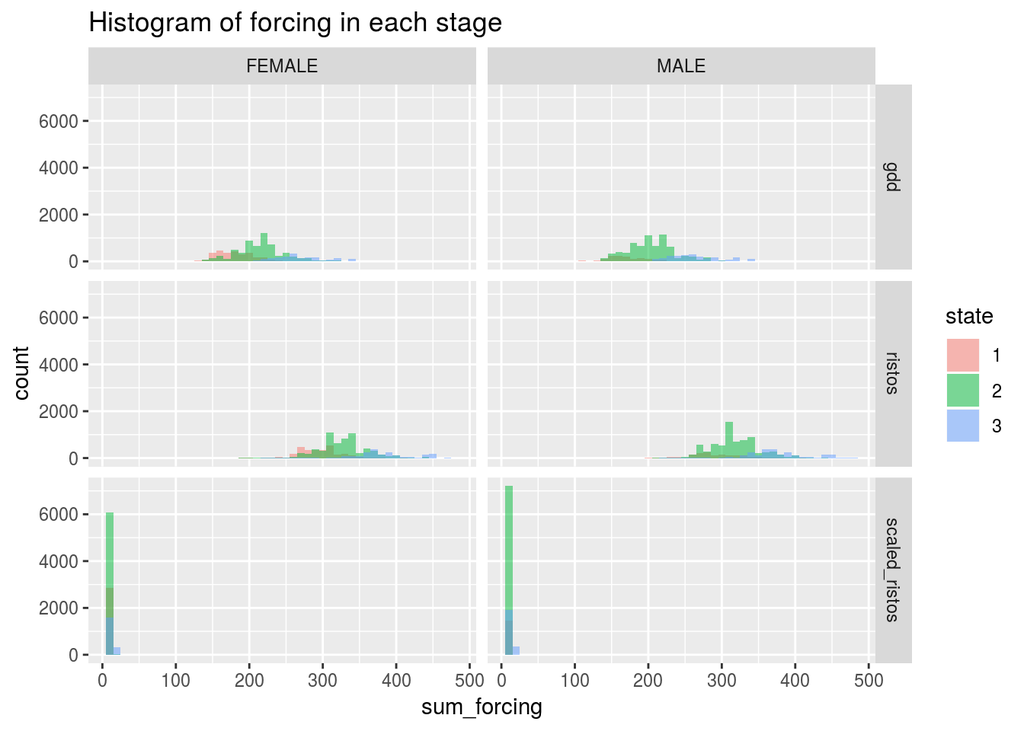

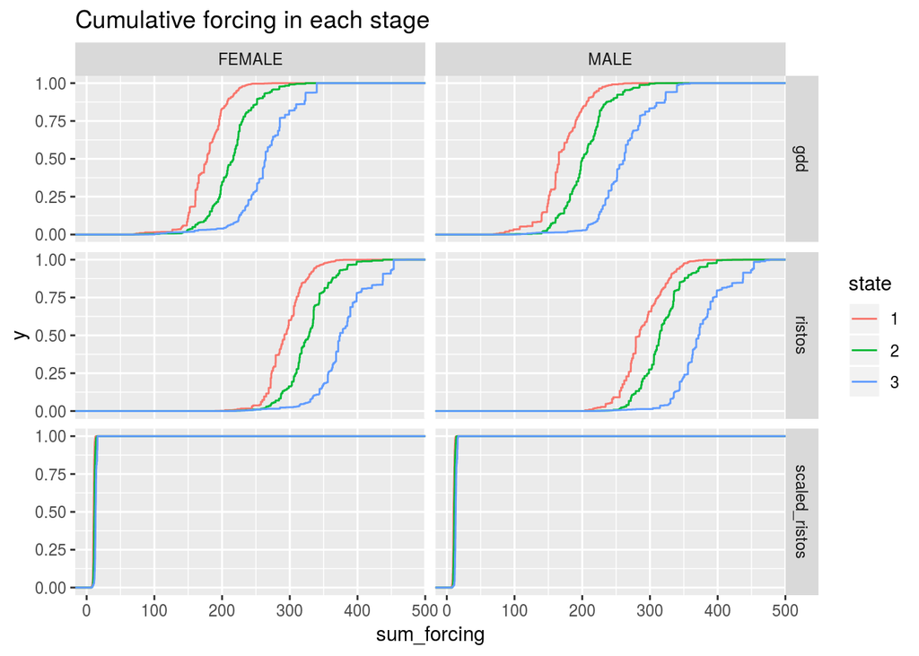

Comparing the range of values each phase occurs over for ristos and GDD, ristos are generally higher. I believe there’s more separation between phase 1 and 2 for GDD than ristos. For the transition from 2 to 3 I believe they are quite similar, though ristos may have more separation. Unclear what will happen with modelling.

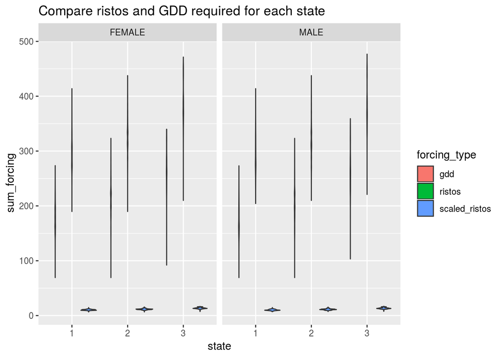

```
##                 df      AIC
## fitmgdd          3 13674.72
## fitmristo        3 13813.27
## fitmristoscaled  3 13813.69
```

```
##                 df      AIC
## fitfgdd          3 15476.85
## fitfristo        3 15560.83
## fitfristoscaled  3 15561.26
```

It looks like growing degree days actually do a better job for the males and females.

Is that true even after accounting for the largest effects? No! After accounting for effects of site and/or provenance and/or orchard, ristos are better. Clone and TreeID leave GDD doing better, but site and prov are the big effects.

```
##                    df      AIC
## fitmgdd_sp         14 12643.77
## fitmristo_sp       14 12571.68
## fitmristoscaled_sp 14 12572.28
```

```
##                    df      AIC
## fitmgdd_sp         14 12643.77
## fitmristo_sp       14 12571.68
## fitfristoscaled_sp 14 14739.02
```

Sticking with ristos! Which is a bit annoying because they are hard to explain.

## Varying slopes - transition state

Next question! Do slopes vary by transition state?

For this I will use logistic models for each transition in each sex.

First let’s have a look at the data.

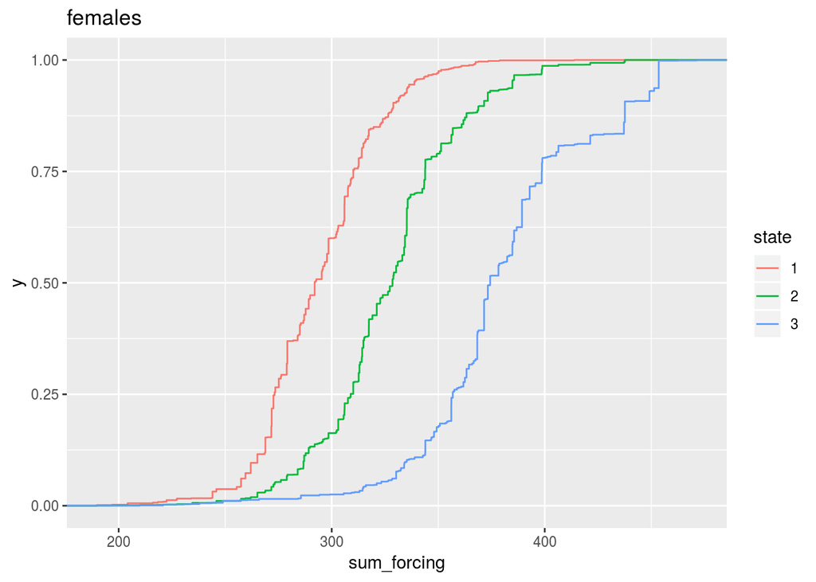

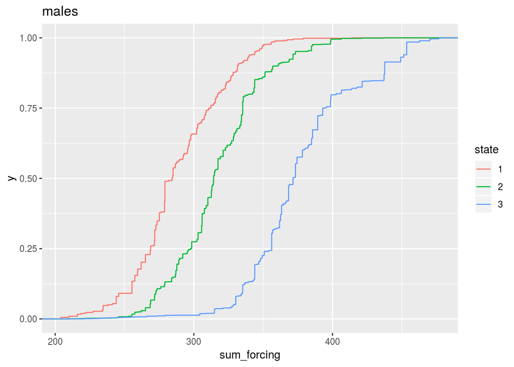

The slope doesn’t look very different overall.

What about when broken down by site?

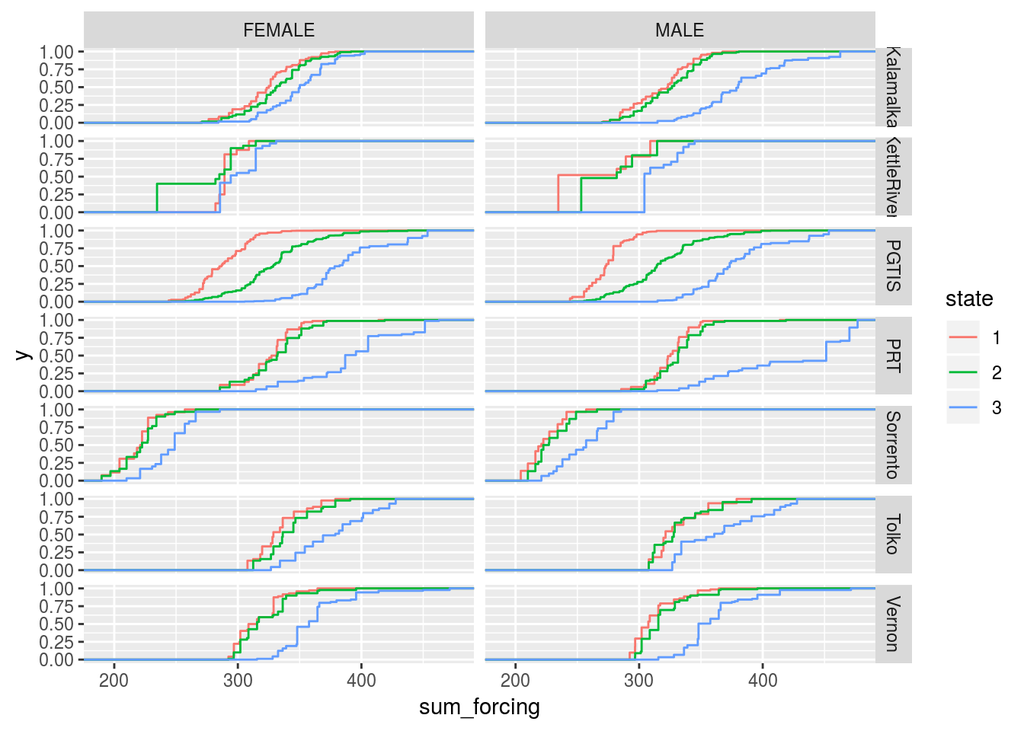

Slope for different transitions does look a bit different at some sites, but only at ones with not-as-good data collection.

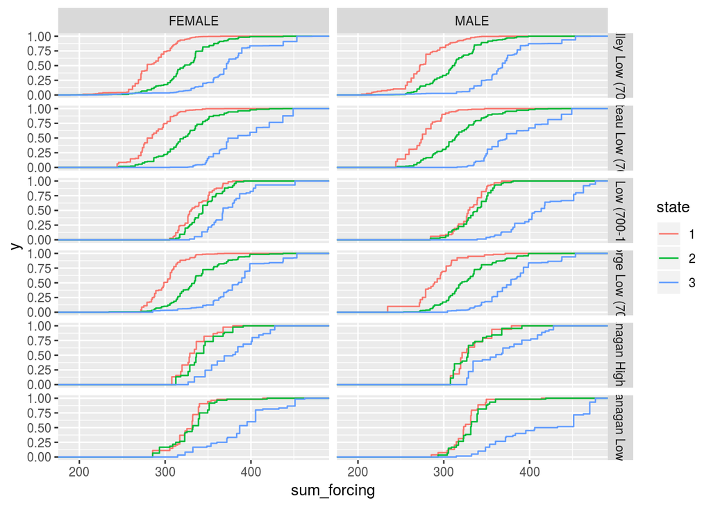

In a lot of these graphs, it kind of looks like the first transition is a Gompertz curve and the 2nd is a logistic. Not sure what to do about that.

Model with logit glm.

```
## (Intercept) sum_forcing
## -7.40860506  0.02972149
```

```
##  (Intercept)  sum_forcing
## -17.79478232   0.04823598
```

```
##  (Intercept)  sum_forcing
## -10.96690709   0.03779244
```

```
##  (Intercept)  sum_forcing
## -15.94827477   0.04197903
```

With the simplest version of the model, the slopes for the different transitions are different, but are pretty close. Given data censorship, I’d say this is fine.

m1, m2, 0.0286474350853425, 0.0471500552613749, 0.0307955466073154, 0.0493218967881484 f1, f2, 0.0368051419069564, 0.0409074261723208, 0.038779735189075, 0.0430506342723842

The first transition is slower than the second transition.

What if I include effects on the slope?

```
##                                              (Intercept)
##                                             -6.703337605
##                                              sum_forcing
##                                              0.019778950
##                                          SiteKettleRiver
##                                              5.541563403
##                                                SitePGTIS
##                                            -12.715093332
##                                                  SitePRT
##                                             -1.801618057
##                                             SiteSorrento
##                                             -0.545751462
##                                                SiteTolko
##                                              5.608748815
##                                               SiteVernon
##                                              0.946924160
##                 SPU_NameCentral Plateau Low (700-1300 m)
##                                              0.883216561
##                          SPU_NameNelson Low (700-1600 m)
##                                              0.995061494
##                   SPU_NamePrince George Low (700-1400 m)
##                                             -3.177923237
##             SPU_NameThompson Okanagan High (1400-1600 m)
##                                                       NA
##               SPU_NameThompson Okanagan Low (700-1400 m)
##                                              3.275771846
##                              sum_forcing:SiteKettleRiver
##                                             -0.013925274
##                                    sum_forcing:SitePGTIS
##                                              0.055434071
##                                      sum_forcing:SitePRT
##                                              0.005739934
##                                 sum_forcing:SiteSorrento
##                                              0.009398998
##                                    sum_forcing:SiteTolko
##                                             -0.017628440
##                                   sum_forcing:SiteVernon
##                                             -0.001479095
##     sum_forcing:SPU_NameCentral Plateau Low (700-1300 m)
##                                             -0.005103994
##              sum_forcing:SPU_NameNelson Low (700-1600 m)
##                                             -0.004425410
##       sum_forcing:SPU_NamePrince George Low (700-1400 m)
##                                              0.007930830
## sum_forcing:SPU_NameThompson Okanagan High (1400-1600 m)
##                                                       NA
##   sum_forcing:SPU_NameThompson Okanagan Low (700-1400 m)
##                                             -0.011380915
```

```
##                                              (Intercept)
##                                            -3.691787e+01
##                                              sum_forcing
##                                             1.098964e-01
##                                          SiteKettleRiver
##                                             2.531770e+00
##                                                SitePGTIS
##                                             1.451668e+01
##                                                  SitePRT
##                                            -2.106177e+02
##                                             SiteSorrento
##                                             1.681568e+01
##                                                SiteTolko
##                                             2.309092e+01
##                                               SiteVernon
##                                             5.204735e+00
##                 SPU_NameCentral Plateau Low (700-1300 m)
##                                             4.406938e+00
##                          SPU_NameNelson Low (700-1600 m)
##                                            -7.180194e+00
##                   SPU_NamePrince George Low (700-1400 m)
##                                             2.951128e+00
##             SPU_NameThompson Okanagan High (1400-1600 m)
##                                                       NA
##               SPU_NameThompson Okanagan Low (700-1400 m)
##                                             2.219853e+02
##                              sum_forcing:SiteKettleRiver
##                                             5.578809e-03
##                                    sum_forcing:SitePGTIS
##                                            -4.776914e-02
##                                      sum_forcing:SitePRT
##                                             5.367587e-01
##                                 sum_forcing:SiteSorrento
##                                            -2.632831e-02
##                                    sum_forcing:SiteTolko
##                                            -6.988751e-02
##                                   sum_forcing:SiteVernon
##                                            -1.435890e-02
##     sum_forcing:SPU_NameCentral Plateau Low (700-1300 m)
##                                            -1.474407e-02
##              sum_forcing:SPU_NameNelson Low (700-1600 m)
##                                             1.113848e-02
##       sum_forcing:SPU_NamePrince George Low (700-1400 m)
##                                            -1.081174e-02
## sum_forcing:SPU_NameThompson Okanagan High (1400-1600 m)
##                                                       NA
##   sum_forcing:SPU_NameThompson Okanagan Low (700-1400 m)
##                                            -5.747683e-01
```

```
##          df      AIC
## fit_mt1   2 6956.717
## fit_met1 22 4801.236
```

```
##          df      AIC
## fit_mt2   2 6562.767
## fit_met2 22 5836.440
```

```
##                                              (Intercept)
##                                             -7.150496750
##                                              sum_forcing
##                                              0.020903572
##                                          SiteKettleRiver
##                                             22.923690969
##                                                SitePGTIS
##                                            -10.774530183
##                                                  SitePRT
##                                              2.820892589
##                                             SiteSorrento
##                                              3.805225629
##                                                SiteTolko
##                                             -1.241492499
##                                               SiteVernon
##                                              1.747984550
##                 SPU_NameCentral Plateau Low (700-1300 m)
##                                              3.503954579
##                          SPU_NameNelson Low (700-1600 m)
##                                             -2.795855463
##                   SPU_NamePrince George Low (700-1400 m)
##                                             -2.873316115
##             SPU_NameThompson Okanagan High (1400-1600 m)
##                                                       NA
##               SPU_NameThompson Okanagan Low (700-1400 m)
##                                              1.159216808
##                              sum_forcing:SiteKettleRiver
##                                             -0.073609617
##                                    sum_forcing:SitePGTIS
##                                              0.041570074
##                                      sum_forcing:SitePRT
##                                             -0.007412486
##                                 sum_forcing:SiteSorrento
##                                             -0.008178450
##                                    sum_forcing:SiteTolko
##                                              0.001925175
##                                   sum_forcing:SiteVernon
##                                             -0.004586696
##     sum_forcing:SPU_NameCentral Plateau Low (700-1300 m)
##                                             -0.011635974
##              sum_forcing:SPU_NameNelson Low (700-1600 m)
##                                              0.006111358
##       sum_forcing:SPU_NamePrince George Low (700-1400 m)
##                                              0.006859970
## sum_forcing:SPU_NameThompson Okanagan High (1400-1600 m)
##                                                       NA
##   sum_forcing:SPU_NameThompson Okanagan Low (700-1400 m)
##                                             -0.005606526
```

```
##                                              (Intercept)
##                                            -1.471830e+01
##                                              sum_forcing
##                                             4.513830e-02
##                                          SiteKettleRiver
##                                            -3.742637e+00
##                                                SitePGTIS
##                                            -6.435360e+00
##                                                  SitePRT
##                                            -5.807737e+02
##                                             SiteSorrento
##                                            -5.743015e+00
##                                                SiteTolko
##                                            -3.441560e+00
##                                               SiteVernon
##                                            -1.555119e+01
##                 SPU_NameCentral Plateau Low (700-1300 m)
##                                             1.518198e+00
##                          SPU_NameNelson Low (700-1600 m)
##                                            -2.771011e+00
##                   SPU_NamePrince George Low (700-1400 m)
##                                             1.328647e+00
##             SPU_NameThompson Okanagan High (1400-1600 m)
##                                                       NA
##               SPU_NameThompson Okanagan Low (700-1400 m)
##                                             5.756522e+02
##                              sum_forcing:SiteKettleRiver
##                                             1.990938e-02
##                                    sum_forcing:SitePGTIS
##                                             1.161011e-02
##                                      sum_forcing:SitePRT
##                                             1.534124e+00
##                                 sum_forcing:SiteSorrento
##                                             4.251614e-02
##                                    sum_forcing:SiteTolko
##                                             5.728678e-03
##                                   sum_forcing:SiteVernon
##                                             4.532878e-02
##     sum_forcing:SPU_NameCentral Plateau Low (700-1300 m)
##                                            -6.035753e-03
##              sum_forcing:SPU_NameNelson Low (700-1600 m)
##                                             3.911964e-03
##       sum_forcing:SPU_NamePrince George Low (700-1400 m)
##                                            -5.858735e-03
## sum_forcing:SPU_NameThompson Okanagan High (1400-1600 m)
##                                                       NA
##   sum_forcing:SPU_NameThompson Okanagan Low (700-1400 m)
##                                            -1.523352e+00
```

```
##          df      AIC
## fit_ft1   2 9141.098
## fit_fet1 22 7736.305
```

```
##          df      AIC
## fit_ft2   2 6130.218
## fit_fet2 22 5253.174
```

Then I get really different slopes for each transition. If I include effects on slope, the second transition is MUCH faster than the first transition. But this model can’t accurately model the slopes- the overall slope is often negative, which is not actually possible biologically!

```
## # A tibble: 24 x 3
##      m1site   m1prov   m1slope
##       <dbl>    <dbl>     <dbl>
##  1 -0.0176  -0.0114  -0.00923
##  2 -0.0176  -0.00510 -0.00295
##  3 -0.0176  -0.00443 -0.00227
##  4 -0.0176   0.00793  0.0101
##  5 -0.0139  -0.0114  -0.00553
##  6 -0.0139  -0.00510  0.000750
##  7 -0.0139  -0.00443  0.00143
##  8 -0.0139   0.00793  0.0138
##  9 -0.00148 -0.0114   0.00692
## 10 -0.00148 -0.00510  0.0132
## # … with 14 more rows
```

I wouldn’t know how to deal with an ordered logistic model where the transitions can have different slopes. Is that even an ordered logistic model anymore? I think I’d have to switch to an HMM model.